# Data Processing

2025-10-30

# 1. data processing

```r
# Example: load a dataset included in the package

# ring measurement
samples69.o <- fread(system.file("extdata", "samples69.csv", package = "CFSTRenD"))

# formatting the users' data conformed to CFSTRenD
samples69.trt <- CFS_format(data = list(samples69.o, 39:111), usage = 1, out.csv = NULL)
```

```
#> [1] "you have filled all the mandatory information"
#> [1] "you have filled all the un-mandatory information"
```

```r
class(samples69.trt)
```

```
#> [1] "cfs_format"
```

```r
# save it to extdata for further use
# saveRDS(samples69.trt, "inst/extdata/samples69.trt.rds")
```

### **arguments of CFS_format() function:**

**data**

All information should be provided in a single file in wide format, with metadata first, followed by the ring-width measurements (in mm).

The column names for the ring-width measurements can follow two formats to indicate the year of measurement: Directly as the year (e.g., 1980) or Prefixed with a character (e.g., X1980).

It is highly recommended that the ring-width measurement columns are ordered by year and consecutive in the dataset, as the column indices will be used as input for the function CFS_format().

**usage**

If users intend to submit their data to the CFSTRenD online repository, set usage = 1 in the function. This will enable the function to format the data structure and perform detailed checks, including column names, geographic coordinates, species, and other requirements to conform to the CFSTRenD collection standards.

Otherwise, use usage = 2 to perform a reduced checking procedure, which still builds the CFSTRenD structure but skips some of the detailed validations.

**out.csv**

if user wants to export the processed tables in csv format, specify the folder here. the default is NULL.

**Note:** Running the function CFS_format() is the first and mandatory step before using any other functions in the CFSTRenD package. The data provided in this tutorial is already prepared to run the vignette; in practice, users may need to add or modify their own data based on the messages generated by the function.

# 2. generate data report:

The data report provides an overview of the tree ring data’s quality and characteristics at four levels: project, project-species, project-species-site, and project-species-radii, including the quality assessment at site and radii levels with the default parameters. More details on quality assessment will be presented next section.

```r
outfile_data <- tempfile(fileext = ".html")
generate_report(robj = samples69.trt, qa.label_data = "CFS-TRenD V1.2 proj69 ", data_report.reports_sel = c(1,2,3,4), qa.min_nseries = 50, output_file = outfile_data)
```

#### **arguments of the generate_report() function:**

**robj**

The input for the data report is the output of the CFS_format() function, which assigns the class “cfs_format” to the resulting object.

**qa.label_data**

A short description of the input dataset. This text will appear in the report as the data source for the generated figures.

**data_report.reports_sel**

**output_file**

This argument allows users to export the HTML-formatted report to a specified location by providing a folder and filename (e.g., “path/to/report.html”). If left as NULL (default), the report will not be saved to disk and will instead open directly in the browser for viewing.

# data summary report

2025-10-30

This report provides an overview of the tree ring data’s quality and characteristics at four levels:

```
1. project: Data Completeness: Assessment of missing or incomplete data of the whole data;
2. project-species: Data Summary: Summary statistics and descriptions;
3. project-species-site: data summary tables and series graphing;
4. project-species-site-radii: Correlation Analysis and quality assessment.
```

project name: **Douglas-fir retrospective monitoring**

selected reports: **1, 2, 3, 4**

### data completeness

This table presents the completeness of each variable of the whole dataset as a percentage. A value of 0 indicates no effective data. Please carefully verify that all required data has been included in the submission.

| var | pct |
| --- | --- |
| tr1_submission_id | 100 |
| tr1_project_name | 100 |
| tr1_description | 100 |
| tr1_year_range | 100 |
| tr1_reference | 100 |
| tr1_open_data | 100 |
| tr1_contact1 | 100 |
| tr1_contact2 | 100 |
| tr2_site_id | 100 |
| tr2_latitude | 100 |
| tr2_longitude | 100 |
| tr2_datasource | 100 |
| tr2_investigators | 100 |

| var | pct |
| --- | --- |
| tr2_province_iso_code | 100 |
| tr3_tree_id | 100 |
| tr3_species | 100 |
| tr4_meas_no | 0 |
| tr4_meas_date | 100 |
| tr4_status | 100 |
| tr4_dbh_cm | 100 |
| tr4_ht_tot_m | 100 |
| tr5_sample_id | 100 |
| tr5_sample_type | 100 |
| tr5_sample_ht_m | 0 |
| tr5_sample_diameter_cm | 0 |

| var | pct |
| --- | --- |
| tr6_radius_id | 100.0 |
| tr6_cofecha_id | 0.0 |
| tr6_ring_meas_method | 100.0 |
| tr6_crossdating_visual | 100.0 |
| tr6_crossdating_validation | 100.0 |
| tr6_age_corrected | 0.0 |
| tr6_bark_thickness_mm | 0.0 |
| tr6_radius_inside_cm | 100.0 |
| tr6_dtc_measured_mm | 100.0 |
| tr6_dtc_estimated_mm | 52.9 |
| tr6_rw_ystart | 100.0 |
| tr6_rw_yend | 100.0 |
| tr6_comments | 0.0 |

### Data Summary (Species)

This section presents key summary statistics, including spatial and temporal ranges, summary of ring width measurements, series length, etc., categorized by species.

In this dataset, there’s 1 species: PSEUMEN

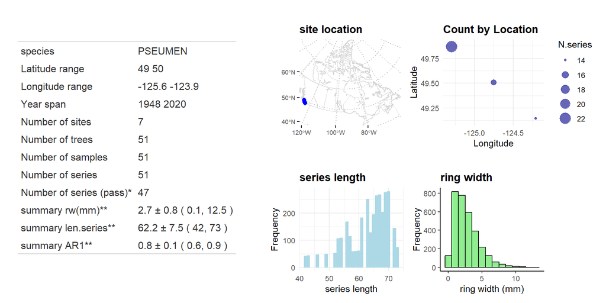

*Number of series that passed the test of CFS_qa() on differentiated series

**The values refer to mean ± sd (min, max)

### site-level data summary

This section presents site-level data summaries, including a figure showing ring width measurements over time and a table with key statistics.

##### PSEUMEN on ring width measurement

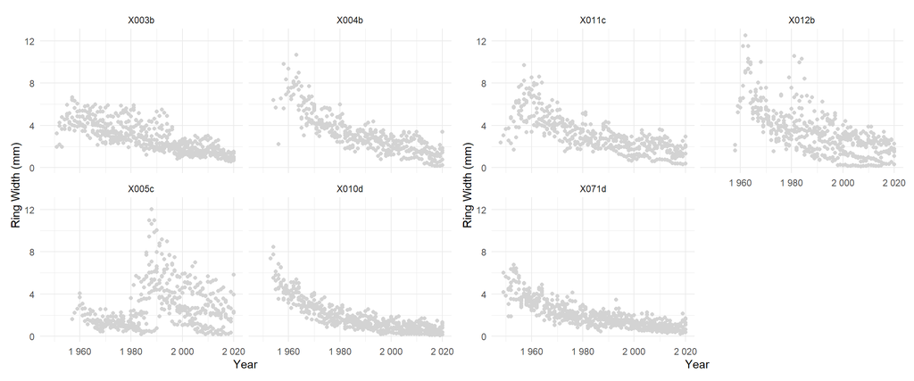

PSEUMEN

| site_id | lon | lat | Nb. trees | len.series** | rw(mm)** |
| --- | --- | --- | --- | --- | --- |
| X003b | -123.9337 | 48.96656 | 8 | 64.3 ± 5.8 ( 54, 70 ) | 2.8 ± 0.6 ( 0.6, 6.6 ) |
| X004b | -123.9952 | 49.05755 | 6 | 60.7 ± 3.8 ( 56, 67 ) | 3.2 ± 0.6 ( 0.1, 10.7 ) |
| X005c | -124.7485 | 49.42990 | 8 | 54.5 ± 6.7 ( 42, 64 ) | 2.8 ± 1 ( 0.1, 12 ) |
| X010d | -124.8184 | 49.43054 | 7 | 65.9 ± 1.5 ( 63, 68 ) | 1.9 ± 0.3 ( 0.1, 8.4 ) |
| X011c | -125.5210 | 50.04691 | 6 | 68.7 ± 2.2 ( 66, 73 ) | 3.1 ± 0.6 ( 0.3, 9.7 ) |
| X012b | -125.5709 | 50.04237 | 8 | 56.5 ± 6.4 ( 43, 63 ) | 3.4 ± 0.8 ( 0.1, 12.5 ) |
| X071d | -125.5010 | 50.03760 | 8 | 69 ± 2.6 ( 64, 72 ) | 2 ± 0.3 ( 0.2, 6.8 ) |

*ratio between median of rw of the site and median of rw of its 10 nearest neighbors.  
**The values refer to mean ± sd (min, max)

### Correlation and quality assessment code

This table provides a summary for each series, including raw ring width measurements, autocorrelation, correlation with master chronology for both raw and differentiated data, and quality assessment code (qa_code) which was derived from the CFS_qa() function. The master chronology includes all the series with qa_code ‘pass’.

Description of qa_code

| qa_code | Description |
| --- | --- |
| pass | The maximum correlation occurs at lag 0 |
| borderline | The correlation at lag 0 ranks as the second highest, and its difference from the maximum remains within a predefined threshold, categorizing as a quasi-pass |
| pm1 | The maximum correlation occurs at lag 1 or -1, suggesting slight misalignment. |
| highpeak | The maximum correlation occurs at a non-zero lag and is more than twice the second-highest value, potentially signaling an issue |
| fail | All other measurements that do not fit into the aforementioned categories fall under this classification. |

PSEUMEN

| site_id | radius_id | year from | year to | len series | raw AR1* | raw corr_mean*& | trt AR1** | trt corr_mean**& | qa_code**% |
| --- | --- | --- | --- | --- | --- | --- | --- | --- | --- |
| X003b | X003_101_001 | 1961 | 2020 | 60 | 0.88 | 0.81 ( 0 ) | -0.38 | 0.57 ( 0 ) | pass |
| X003b | X003_101_002 | 1956 | 2020 | 65 | 0.89 | 0.92 ( 0 ) | -0.40 | 0.49 ( 0 ) | pass |
| X003b | X003_101_003 | 1965 | 2020 | 56 | 0.87 | 0.92 ( 0 ) | -0.38 | 0.52 ( 0 ) | pass |
| X003b | X003_101_004 | 1951 | 2020 | 70 | 0.88 | 0.85 ( 0 ) | -0.43 | 0.58 ( 0 ) | pass |
| X003b | X003_101_005 | 1951 | 2020 | 70 | 0.85 | 0.86 ( 0 ) | -0.36 | 0.39 ( 0 ) | pass |
| X003b | X003_101_006 | 1952 | 2020 | 69 | 0.88 | 0.9 ( 0 ) | -0.51 | 0.48 ( 0 ) | pass |
| X003b | X003_101_007 | 1955 | 2020 | 66 | 0.85 | 0.84 ( 0 ) | -0.27 | 0.3 ( 0.01 ) | pass |
| X003b | X003_101_008 | 1967 | 2020 | 54 | 0.79 | 0.88 ( 0 ) | -0.45 | 0.54 ( 0 ) | pass |
| X004b | X004_101_001 | 1965 | 2020 | 56 | 0.79 | 0.82 ( 0 ) | -0.25 | 0.51 ( 0 ) | pass |
| X004b | X004_101_002 | 1958 | 2020 | 63 | 0.84 | 0.94 ( 0 ) | -0.33 | 0.4 ( 0 ) | pass |
| X004b | X004_101_003 | 1960 | 2020 | 61 | 0.92 | 0.91 ( 0 ) | -0.01 | 0.39 ( 0 ) | pass |
| X004b | X004_101_004 | 1954 | 2020 | 67 | 0.76 | 0.84 ( 0 ) | -0.37 | 0.66 ( 0 ) | pass |
| X004b | X004_101_007 | 1962 | 2020 | 59 | 0.89 | 0.89 ( 0 ) | -0.06 | 0.5 ( 0 ) | pass |
| X004b | X004_101_008 | 1964 | 2020 | 57 | 0.83 | 0.9 ( 0 ) | -0.69 | 0.58 ( 0 ) | pass |
| X005c | X005_101_001 | 1964 | 2009 | 46 | 0.92 | 0.26 ( 0.08 ) | 0.31 | 0.34 ( 0.02 ) | pass |
| X005c | X005_101_002 | 1960 | 2016 | 57 | 0.90 | 0.22 ( 0.1 ) | 0.29 | 0.26 ( 0.06 ) | pass |
| X005c | X005_101_003 | 1979 | 2020 | 42 | 0.88 | 0.25 ( 0.12 ) | 0.11 | 0.52 ( 0 ) | pass |
| X005c | X005_101_004 | 1967 | 2020 | 54 | 0.90 | 0.11 ( 0.43 ) | 0.15 | 0.52 ( 0 ) | pass |
| X005c | X005_101_005 | 1957 | 2020 | 64 | 0.92 | -0.23 ( 0.07 ) | -0.01 | 0.29 ( 0.02 ) | pass |
| X005c | X005_101_006 | 1966 | 2018 | 53 | 0.80 | 0.06 ( 0.68 ) | -0.37 | 0.47 ( 0 ) | pass |
| X005c | X005_101_007 | 1968 | 2019 | 52 | 0.91 | 0.25 ( 0.08 ) | 0.07 | 0.26 ( 0.06 ) | borderline |
| X005c | X005_101_008 | 1960 | 2020 | 61 | 0.93 | -0.31 ( 0.02 ) | 0.17 | 0.33 ( 0.01 ) | pass |
| X010d | X010_104_001 | 1956 | 2020 | 65 | 0.89 | 0.93 ( 0 ) | -0.30 | 0.71 ( 0 ) | pass |
| X010d | X010_104_002 | 1954 | 2020 | 67 | 0.85 | 0.93 ( 0 ) | -0.56 | 0.77 ( 0 ) | pass |
| X010d | X010_104_003 | 1956 | 2020 | 65 | 0.91 | 0.93 ( 0 ) | -0.40 | 0.67 ( 0 ) | pass |
| X010d | X010_104_005 | 1958 | 2020 | 63 | 0.73 | 0.89 ( 0 ) | -0.29 | 0.39 ( 0 ) | pass |
| X010d | X010_104_006 | 1953 | 2020 | 68 | 0.86 | 0.91 ( 0 ) | -0.47 | 0.65 ( 0 ) | pass |
| X010d | X010_104_007 | 1955 | 2020 | 66 | 0.85 | 0.88 ( 0 ) | -0.54 | -0.27 ( 0.03 ) | pm1 |
| X010d | X010_104_008 | 1954 | 2020 | 67 | 0.87 | 0.92 ( 0 ) | -0.29 | 0.65 ( 0 ) | pass |
| X011c | X011_101_002 | 1955 | 2020 | 66 | 0.89 | 0.88 ( 0 ) | -0.13 | 0.72 ( 0 ) | pass |
| X011c | X011_101_004 | 1951 | 2019 | 69 | 0.89 | 0.87 ( 0 ) | -0.16 | 0.57 ( 0 ) | pass |
| X011c | X011_101_005 | 1953 | 2020 | 68 | 0.91 | 0.92 ( 0 ) | -0.35 | 0.6 ( 0 ) | pass |
| X011c | X011_101_006 | 1952 | 2020 | 69 | 0.84 | 0.9 ( 0 ) | -0.37 | 0.15 ( 0.23 ) | Fail |
| X011c | X011_101_007 | 1954 | 2020 | 67 | 0.82 | 0.91 ( 0 ) | -0.31 | 0.66 ( 0 ) | pass |
| X011c | X011_101_008 | 1948 | 2020 | 73 | 0.91 | 0.9 ( 0 ) | -0.21 | 0.64 ( 0 ) | pass |
| X012b | X012_102_001 | 1978 | 2020 | 43 | 0.82 | 0.75 ( 0 ) | -0.42 | 0.56 ( 0 ) | pass |
| X012b | X012_102_002 | 1963 | 2015 | 53 | 0.77 | 0.9 ( 0 ) | -0.24 | 0.84 ( 0 ) | pass |
| X012b | X012_102_003 | 1958 | 2020 | 63 | 0.86 | 0.9 ( 0 ) | -0.36 | 0.03 ( 0.81 ) | Fail |
| X012b | X012_102_004 | 1965 | 2020 | 56 | 0.61 | 0.82 ( 0 ) | -0.48 | 0.77 ( 0 ) | pass |
| X012b | X012_102_005 | 1960 | 2020 | 61 | 0.76 | 0.87 ( 0 ) | -0.25 | 0.62 ( 0 ) | pass |
| X012b | X012_102_006 | 1963 | 2020 | 58 | 0.66 | 0.78 ( 0 ) | -0.48 | 0.7 ( 0 ) | pass |
| X012b | X012_102_007 | 1958 | 2020 | 63 | 0.81 | 0.93 ( 0 ) | -0.18 | 0.76 ( 0 ) | pass |
| X012b | X012_102_008 | 1965 | 2013 | 49 | 0.78 | 0.78 ( 0 ) | -0.57 | 0.68 ( 0 ) | pass |
| X071d | X071_104_001 | 1949 | 2020 | 72 | 0.88 | 0.91 ( 0 ) | -0.32 | 0.76 ( 0 ) | pass |
| X071d | X071_104_002 | 1949 | 2020 | 72 | 0.82 | 0.93 ( 0 ) | -0.31 | 0.74 ( 0 ) | pass |
| X071d | X071_104_003 | 1957 | 2020 | 64 | 0.75 | 0.85 ( 0 ) | -0.52 | 0.54 ( 0 ) | pass |
| X071d | X071_104_004 | 1952 | 2020 | 69 | 0.82 | 0.82 ( 0 ) | -0.33 | 0.63 ( 0 ) | pass |
| X071d | X071_104_005 | 1951 | 2018 | 68 | 0.88 | 0.84 ( 0 ) | -0.48 | 0.69 ( 0 ) | pass |
| X071d | X071_104_006 | 1951 | 2020 | 70 | 0.87 | 0.93 ( 0 ) | -0.35 | 0.75 ( 0 ) | pass |
| X071d | X071_104_007 | 1955 | 2020 | 66 | 0.78 | 0.92 ( 0 ) | -0.52 | 0.64 ( 0 ) | pass |
| X071d | X071_104_008 | 1951 | 2020 | 70 | 0.89 | 0.93 ( 0 ) | -0.40 | 0.71 ( 0 ) | pass |

*developed from raw series  
**developed from differentiated series  
&correlation with master chronology, the value represents correlation (p-value)  
%qa_code is identified using the current data as reference dataset